# Supervised_Learning_Project

```python
smote_nc = SMOTENC(categorical_features = [1, 3, 5], random_state = 1)
X_s, y_s = smote_nc.fit_resample(X, y)
```

```python
print('Before sampling: ')
print(y.value_counts())
```

```
Before sampling:
0.0    4500
1.0     480
Name: LoanOnCard, dtype: int64
```

```python
print('After sampling: ')
print(y_s.value_counts())
```

```
After sampling:
0.0    4500
1.0    4500
Name: LoanOnCard, dtype: int64
```

After sampling balanced data

```python
# Split X and y into training and test set in 70:30 ratio

X_train, X_test, y_train, y_test = train_test_split(X, y, test_size = 0.30, random_state = 1)
```

```python
logisticRegression = LogisticRegression()
logisticRegression.fit(X_train, y_train)
```

[output not shown]

```
LogisticRegression()
```

```python
predicted_labels = logisticRegression.predict(X_test)

print('Accuracy on Training data: ', logisticRegression.score(X_train, y_train))
print('Accuracy on Test data: ', logisticRegression.score(X_test, y_test))
```

```
Accuracy on Training data:  0.9523809523809523
Accuracy on Test data:  0.9451137884872824
```

```python
confusion_matrix(y_test, predicted_labels)
```

```
array([[1326,   15],
       [  67,   86]], dtype=int64)
```

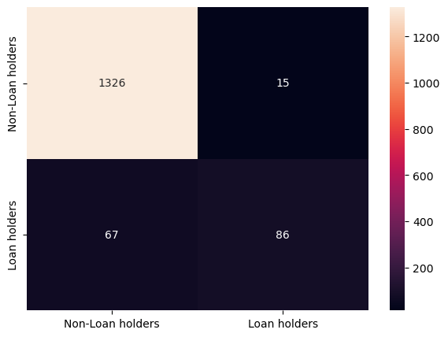

```python
# calculate accuracy measures and confusion matrix

cm = confusion_matrix(y_test, predicted_labels)
df_cm = pd.DataFrame(cm, index = [i for i in ["Non-Loan holders","Loan holders"]], columns = [i for i in ["Non-Loan holders","Loan holders"]])
plt.figure(figsize = (7, 5))
sns.heatmap(df_cm, annot = True, fmt = 'g')
plt.show()
```

```python
classification_report(y_test, predicted_labels)
```

```
'              precision    recall  f1-score   support\n\n         0.0       0.95      0.99      0.97      1341\n         1.0       0.85      0.56      0.68       153\n\n    accuracy                           0.95      1494\n   macro avg       0.90      0.78      0.82      1494\nweighted avg       0…
```

F. Again train the same previous model on balanced data. [1 Marks]

```python
# Split X and y into training and test set in 70:30 ratio

X_train, X_test, y_train, y_test = train_test_split(X, y, test_size = 0.30, random_state = 1)
```

```python
smote_nc = SMOTENC(categorical_features = [1, 3, 5], random_state = 1)
X_train_res, y_train_res = smote_nc.fit_resample(X_train, y_train)
```

```python
logisticRegression_res = LogisticRegression()
logisticRegression_res.fit(X_train_res, y_train_res)
```

[output not shown]

```
LogisticRegression()
```

```python
predicted_labels = logisticRegression_res.predict(X_test)

print('Accuracy on Training data: ', logisticRegression.score(X_train, y_train))
print('Accuracy on Test data: ', logisticRegression.score(X_test, y_test))
```

```
Accuracy on Training data:  0.9523809523809523
Accuracy on Test data:  0.9451137884872824
```

G. Print evaluation metrics and clearly share differences observed. [2 Marks]

```python
confusion_matrix(y_test, predicted_labels)
```

```
array([[1185,  156],
       [  24,  129]], dtype=int64)
```

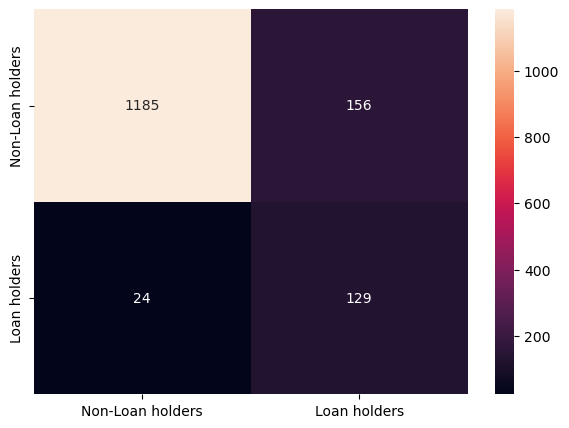

```python
# calculate accuracy measures and confusion matrix

cm = confusion_matrix(y_test, predicted_labels)
df_cm = pd.DataFrame(cm, index = [i for i in ["Non-Loan holders","Loan holders"]], columns = [i for i in ["Non-Loan holders","Loan holders"]])
plt.figure(figsize = (7, 5))
sns.heatmap(df_cm, annot = True, fmt = 'g')
plt.show()
```

```python
classification_report(y_test, predicted_labels)
```

```
'              precision    recall  f1-score   support\n\n         0.0       0.98      0.88      0.93      1341\n         1.0       0.45      0.84      0.59       153\n\n    accuracy                           0.88      1494\n   macro avg       0.72      0.86      0.76      1494\nweighted avg       0…
```

1. Performance Improvement: [10 Marks]

A. Train a base model each for SVM, KNN. [4 Marks]

```python
KNN = KNeighborsClassifier(n_neighbors= 5, metric = 'euclidean')
KNN.fit(X_train, y_train)
```

```
KNeighborsClassifier(metric='euclidean')
```

```python
predicted_labels = KNN.predict(X_test)

print('Accuracy on Training data: ', KNN.score(X_train, y_train))
print('Accuracy on Test data: ', KNN.score(X_test, y_test))
```

```
Accuracy on Training data:  0.9403327596098681
Accuracy on Test data:  0.9002677376171352
```

```python
confusion_matrix(y_test, predicted_labels)
```

```
array([[1300,   41],
       [ 108,   45]], dtype=int64)
```

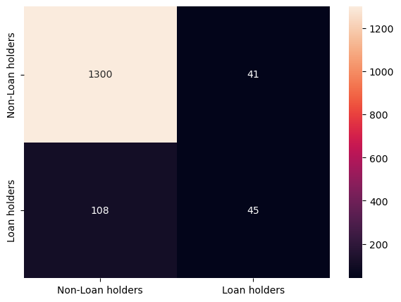

```python
# calculate accuracy measures and confusion matrix

cm = confusion_matrix(y_test, predicted_labels)
df_cm = pd.DataFrame(cm, index = [i for i in ["Non-Loan holders","Loan holders"]], columns = [i for i in ["Non-Loan holders","Loan holders"]])
plt.figure(figsize = (7, 5))
sns.heatmap(df_cm, annot = True, fmt = 'g')
plt.show()
```

```python
classification_report(y_test, predicted_labels)
```

```
'              precision    recall  f1-score   support\n\n         0.0       0.92      0.97      0.95      1341\n         1.0       0.52      0.29      0.38       153\n\n    accuracy                           0.90      1494\n   macro avg       0.72      0.63      0.66      1494\nweighted avg       0…
```

```python
def getAccuracy(testSet, predictions):
    correct = 0
    for x in range(len(testSet)):
        if testSet[x]== predictions[x]:
            correct += 1
    return (correct/float(len(testSet))) * 100.0
```

```python
X,y = np.array(df_merged)[ :, 1:16], np.array(df_merged.LoanOnCard)[:]   # note for y, extracting all rows of "letter" col
```

```python
# Split X and y into training and test set in 70:30 ratio

X_train, X_test, y_train, y_test = train_test_split(X, y, test_size = 0.30, random_state = 1)
```

```python
# gamma is a measure of influence of a data point. It is inverse of distance of influence. C is penalty of wrong classifications.

clf = svm.SVC(gamma=0.025, C=3)
```

```python
clf.fit(X_train , y_train)
```

```
SVC(C=3, gamma=0.025)
```

```python
y_pred = clf.predict(X_test)
```

```python
getAccuracy(y_test , y_pred)   # Calling getAccuracy function instead of usinig array comparison to get the %age accuracy
```

```
93.37349397590361
```

```python
y_grid = (np.column_stack([y_test, y_pred]))
y_grid
```

```
array([[0., 0.],
       [0., 0.],
       [0., 0.],
       ...,
       [0., 0.],
       [0., 0.],
       [0., 0.]])
```

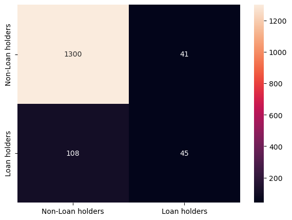

```python
# calculate accuracy measures and confusion matrix

cm = confusion_matrix(y_test, predicted_labels)
df_cm = pd.DataFrame(cm, index = [i for i in ["Non-Loan holders","Loan holders"]], columns = [i for i in ["Non-Loan holders","Loan holders"]])
plt.figure(figsize = (7, 5))
sns.heatmap(df_cm, annot = True, fmt = 'g')
plt.show()
```

B. Tune parameters for each of the models wherever required and finalize a model. [3 Marks]

(Optional: Experiment with various Hyperparameters - Research required)

```python
LR_model=LogisticRegression()
KNN_model=KNeighborsClassifier(n_neighbors=13)
GN_model=GaussianNB()
svc_model_linear = SVC(kernel='linear', C=1, gamma=.6)
svc_model_rbf = SVC(kernel='rbf', degree=2, C=.009)
svc_model_poly  = SVC(kernel='poly', degree=2, gamma=0.1, C=.01)
```

```python
seed = 7

# prepare models
models = []
models.append(('LR', LR_model))
models.append(('KNN', KNN_model))
models.append(('NB', GN_model))
models.append(('SVM-linear', svc_model_linear))
models.append(('SVM-poly', svc_model_poly))
models.append(('SVM-rbf', svc_model_rbf))

# evaluate each model in turn
results = []
names = []
scoring = 'accuracy'
for name, model in models:
    kfold = model_selection.KFold(n_splits = 10, random_state = seed, shuffle = True)
    cv_results = model_selection.cross_val_score(model, X, y, cv = kfold, scoring = scoring)
    results.append(cv_results)
    names.append(name)
    msg = "%s: %f (%f)" % (name, cv_results.mean(), cv_results.std())
    print(msg)
```

[output not shown]

[output cut: 25 more lines]

[output not shown]

```
LR: 1.000000 (0.000000)
KNN: 0.913052 (0.017939)
NB: 1.000000 (0.000000)
SVM-linear: 1.000000 (0.000000)
SVM-poly: 1.000000 (0.000000)
SVM-rbf: 0.903614 (0.019592)
```

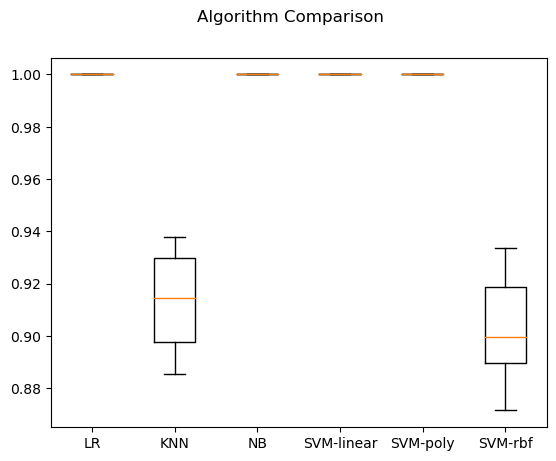

```python
# boxplot algorithm comparison
fig = plt.figure()
fig.suptitle('Algorithm Comparison')

ax = fig.add_subplot(111)
plt.boxplot(results)
ax.set_xticklabels(names)
plt.show()
```

D. Share improvement achieved from base model to final model. [2 Marks]

```
We are selecting final model as logistic regression as it performs well in training and testing test.

Logistic Regression is not affected by overfitting and it is also has good recall value.

Logistic regression performed well in k-fold cross validation as well.

Deviation also less in logistic regression.

Sampling improved to predict minority classes as well

Suggesting to collect data equally for both the classes.

Few customers does't have credit card but those customer having loan on card. This data error can be avoided
```